# Trabajo Final - Análisis Exploratorio de Datos

Mariam Parra Cárdenas, David Michel García Batista, Kevin Corbo González, Luis Manuel Notario Pérez

Mayo-2025

### Introducción

> El conjunto de datos `airquality`, disponible en el entorno estadístico **R Studio**, contiene observaciones diarias de variables desde el 1ro de Mayo hasta el 30 de Septiembre,1973, relacionadas con la calidad del aire y condiciones meteorológicas. Las variables registradas incluyen: -Ozone: Ozono medio en partes por mil millones entre las 13.00 y las 15.00 horas en Roosevelt Island -Solar.R: Radiación solar en Langleys en la banda de frecuencia 4000–7700 Angstroms de 08:00 a 12:00 horas en Central Park -Wind: Velocidad media del viento en millas por hora a las 07:00 y a las 10:00 horas en el Aeropuerto LaGuardia -Temp: Temperatura máxima diaria en grados Fahrenheit en el Aeropuerto LaGuardia.

> Este trabajo tiene como objetivo aplicar un **análisis exploratorio de datos (AED)** exhaustivo, que permita descubrir patrones relevantes, relaciones entre variables y fenómenos no evidentes a primera vista. Lejos de limitarse a una descripción superficial, este enfoque busca:

> 1.**Comprender la estructura interna del dataset**, evaluando la distribución, presencia de outliers, sesgos y comportamientos atípicos en cada variable.  
> 2. **Detectar interacciones ambientales** entre los distintos factores meteorológicos y de contaminación, como la posible influencia de la radiación solar o el viento sobre los niveles de ozono.  
> 3. **Identificar patrones complejos**, como la bimodalidad o agrupamientos estacionales, que solo emergen mediante una visualización y análisis cuidadoso. Esto nos permitirá construir **hipótesis sólidas a partir de datos brutos** aprovechando herramientas como histogramas, boxplots y medidas de resumen (medianas, percentiles, IQR) para interpretar adecuadamente fenómenos ambientales.

## Carga de bibliotecas necesarias

```r
library(graphics)
library(ggplot2)
library(dplyr)
library(tidyr)
library(GGally)
library(psych)
library(ggpubr)
library(gridExtra)
library(openair)
```

> Se cargan las bibliotecas que se usarán para el análisis, la limpieza, y la visualización de datos.

## Carga y exploración inicial de la base de datos

> Se utiliza el dataset `airquality` incluido en R para construir el dataframe (df). Se revisa su estructura general, cantidad de filas y columnas, valores faltantes, estadísticas básicas y matriz de correlación inicial. Observamos la presencia de valores NA en las variables Ozone y Solar.R. Procedemos a eliminar las filas con valores ausentes para trabajar solo con observaciones completas. Luego se repite la exploración básica para ver los cambios.

```r
df <- datasets::airquality
dim(df)
```

```
## [1] 153   6
```

```r
str(df)
```

```
## 'data.frame':    153 obs. of  6 variables:
##  $ Ozone  : int  41 36 12 18 NA 28 23 19 8 NA ...
##  $ Solar.R: int  190 118 149 313 NA NA 299 99 19 194 ...
##  $ Wind   : num  7.4 8 12.6 11.5 14.3 14.9 8.6 13.8 20.1 8.6 ...
##  $ Temp   : int  67 72 74 62 56 66 65 59 61 69 ...
##  $ Month  : int  5 5 5 5 5 5 5 5 5 5 ...
##  $ Day    : int  1 2 3 4 5 6 7 8 9 10 ...
```

```r
sum(is.na(df))
```

```
## [1] 44
```

```r
summary(df)
```

```
##      Ozone           Solar.R           Wind             Temp
##  Min.   :  1.00   Min.   :  7.0   Min.   : 1.700   Min.   :56.00
##  1st Qu.: 18.00   1st Qu.:115.8   1st Qu.: 7.400   1st Qu.:72.00
##  Median : 31.50   Median :205.0   Median : 9.700   Median :79.00
##  Mean   : 42.13   Mean   :185.9   Mean   : 9.958   Mean   :77.88
##  3rd Qu.: 63.25   3rd Qu.:258.8   3rd Qu.:11.500   3rd Qu.:85.00
##  Max.   :168.00   Max.   :334.0   Max.   :20.700   Max.   :97.00
##  NA's   :37       NA's   :7
##      Month            Day
##  Min.   :5.000   Min.   : 1.0
##  1st Qu.:6.000   1st Qu.: 8.0
##  Median :7.000   Median :16.0
##  Mean   :6.993   Mean   :15.8
##  3rd Qu.:8.000   3rd Qu.:23.0
##  Max.   :9.000   Max.   :31.0
##
```

```r
cor(df)
```

```
##         Ozone Solar.R       Wind       Temp        Month          Day
## Ozone       1      NA         NA         NA           NA           NA
## Solar.R    NA       1         NA         NA           NA           NA
## Wind       NA      NA  1.0000000 -0.4579879 -0.178292579  0.027180903
## Temp       NA      NA -0.4579879  1.0000000  0.420947252 -0.130593175
## Month      NA      NA -0.1782926  0.4209473  1.000000000 -0.007961763
## Day        NA      NA  0.0271809 -0.1305932 -0.007961763  1.000000000
```

## Limpieza de datos: eliminación de valores faltantes (NA)

```r
df <- df %>%
  drop_na()

dim(df)
```

```
## [1] 111   6
```

```r
str(df)
```

```
## 'data.frame':    111 obs. of  6 variables:
##  $ Ozone  : int  41 36 12 18 23 19 8 16 11 14 ...
##  $ Solar.R: int  190 118 149 313 299 99 19 256 290 274 ...
##  $ Wind   : num  7.4 8 12.6 11.5 8.6 13.8 20.1 9.7 9.2 10.9 ...
##  $ Temp   : int  67 72 74 62 65 59 61 69 66 68 ...
##  $ Month  : int  5 5 5 5 5 5 5 5 5 5 ...
##  $ Day    : int  1 2 3 4 7 8 9 12 13 14 ...
```

```r
summary(df)
```

```
##      Ozone          Solar.R           Wind            Temp
##  Min.   :  1.0   Min.   :  7.0   Min.   : 2.30   Min.   :57.00
##  1st Qu.: 18.0   1st Qu.:113.5   1st Qu.: 7.40   1st Qu.:71.00
##  Median : 31.0   Median :207.0   Median : 9.70   Median :79.00
##  Mean   : 42.1   Mean   :184.8   Mean   : 9.94   Mean   :77.79
##  3rd Qu.: 62.0   3rd Qu.:255.5   3rd Qu.:11.50   3rd Qu.:84.50
##  Max.   :168.0   Max.   :334.0   Max.   :20.70   Max.   :97.00
##      Month            Day
##  Min.   :5.000   Min.   : 1.00
##  1st Qu.:6.000   1st Qu.: 9.00
##  Median :7.000   Median :16.00
##  Mean   :7.216   Mean   :15.95
##  3rd Qu.:9.000   3rd Qu.:22.50
##  Max.   :9.000   Max.   :31.00
```

```r
cor(df)
```

```
##                Ozone     Solar.R        Wind       Temp        Month
## Ozone    1.000000000  0.34834169 -0.61249658  0.6985414  0.142885168
## Solar.R  0.348341693  1.00000000 -0.12718345  0.2940876 -0.074066683
## Wind    -0.612496576 -0.12718345  1.00000000 -0.4971897 -0.194495804
## Temp     0.698541410  0.29408764 -0.49718972  1.0000000  0.403971709
## Month    0.142885168 -0.07406668 -0.19449580  0.4039717  1.000000000
## Day     -0.005189769 -0.05775380  0.04987102 -0.0965458 -0.009001079
##                  Day
## Ozone   -0.005189769
## Solar.R -0.057753801
## Wind     0.049871017
## Temp    -0.096545800
## Month   -0.009001079
## Day      1.000000000
```

> Podemos apreciar el cambio de los valores, entre ellos notamos como ahora aparece una correlación prácticamente fuerte entre las variables Ozone y Temp. Más adelante trabajaremos esto

## Construcción de histogramas para las primeras cuatro variables

> Comenazaremos el análisis del dataframe mediante la utilización de histogramas con el objetivo de: -Explorar la distribución de cada variable (¿es simétrica, sesgada, bimodal?). -Identificar valores atípicos (colas largas o barras aisladas). -Verificar supuestos de normalidad o necesidad de transformaciones.

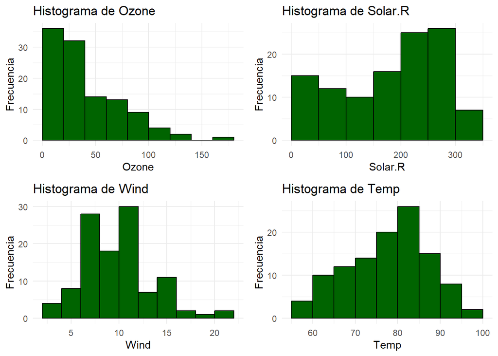

```r
datos <- df[, 1:4] #lista para contener las 4 primeras columnas df

#Función anónima para ajustar el número de barras segun la regla de Sturges
nclass.Sturges <- function(x) {
  ceiling(log2(length(na.omit(x))) + 1)
}

plots <- list() #lista para guardar los histogramas

#ciclo para ir tomando cada columna y guardar el nombre de la variable en col_name y el contenido en col_data
for (i in 1:ncol(datos)) {
  col_name <- names(datos)[i]
  col_data <- datos[[col_name]]
  #el nombre lo explica solo :)
  numbarras <- pretty(range(col_data),
                      n = nclass.Sturges(col_data),
                      min.n = 1)
  #construye cada histograma y lo guarda dentro de plots en la posición i
  plots[[i]] <- ggplot(data.frame(col_data), aes(x = col_data)) +
    geom_histogram(breaks = numbarras,
                   color = "black",
                   fill = "darkgreen") +
    labs(title = paste("Histograma de", col_name),
         x = col_name,
         y = "Frecuencia") +
    theme_minimal()
}
#grafica cada histograma agrupados en un formato de 2x2
grid.arrange(grobs = plots, ncol = 2)
```

## Boxplots múltiples para visualizar la dispersión de las variables

> Queremos visualizar de forma compacta la dispersión, la simetría y los valores extremos de la distribución. En este caso utilizaremos Boxplots para identificar patrones, detectar outliers y anticipar decisiones de modelado estadístico.

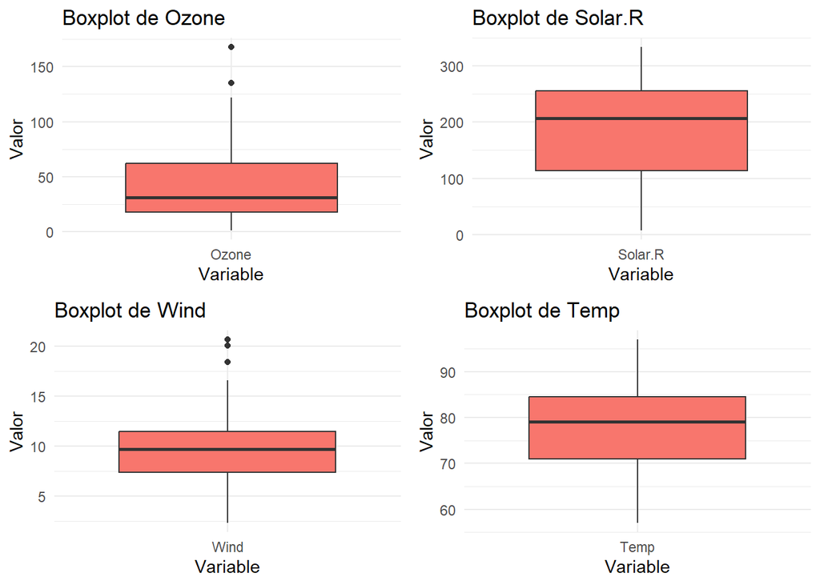

```r
df_long <- pivot_longer(df,
                        cols = c(Ozone, Solar.R, Wind, Temp),
                        names_to = "Variable",
                        values_to = "Valor")

boxplots_list <- lapply(unique(df_long$Variable), function(var) {
  ggplot(df_long %>% filter(Variable == var), aes(x = Variable, y = Valor, fill = Variable)) +
    geom_boxplot() +
    labs(title = paste("Boxplot de", var)) +
    theme_minimal() +
    theme(legend.position = "none")  # Ocultar leyenda individual
})

grid.arrange(grobs = boxplots_list,ncol = 2
)
```

## Resumen gráfico de los datos con summaryPlot

> Para cada variable —**Temp**, **Wind**, **Solar.R** y **Ozone**— utilizaremos gráficos compuestos que integran: 1. **Proporción de datos faltantes** (indicador visual).  
> 2. **Serie diaria** representada como línea continua.  
> 3. **Resumen estadístico**: media, mediana y percentil 95.  
> 4. **Mini-histograma** de la distribución global.

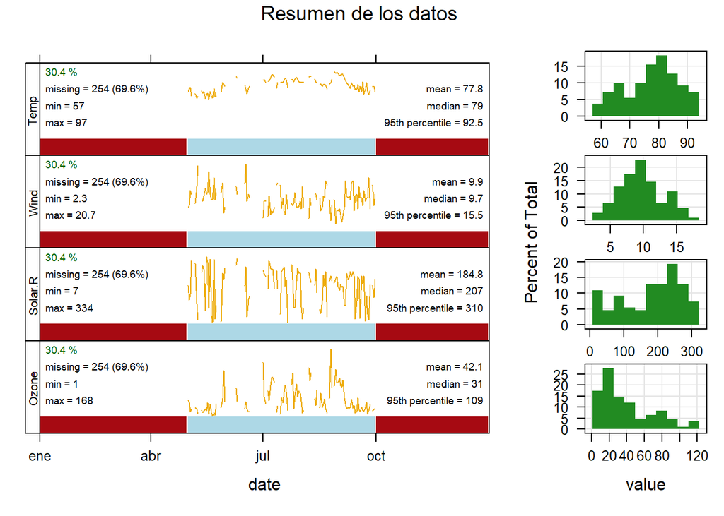

```r
#Se crea una columna 'date' necesaria para utilizar el método 'summaryPlot
#ésta contiene la fecha en formato YY-MM-DD'
df$date <- as.Date(paste("1973", df$Month, df$Day, sep = "-"))

summaryPlot(
  df[,!names(df) %in% c("Day","Month")],
  main = "Resumen de los datos"
)
```

## Resultados

- **Temp**
  - Tendencia: ascenso de ~60 °F en mayo a ~90 °F en julio, luego descenso hasta septiembre.
  - Distribución: casi normal; media = 77.8 °F, mediana = 79 °F, p95 = 92.5 °F.
- **Wind**
  - Patrón diario: ligeras fluctuaciones; vientos más suaves en junio–julio.
  - Distribución: casi simétrica; moda = 8–11 mph, mediana = 9.7 mph, p95 = 15.5 mph.
- **Solar.R**
  - Comportamiento: valores erráticos en primavera; mesetas altas en junio–julio.
  - Distribución bimodal: cúmulos en 0–50 Ly y 200–300 Ly; mediana = 207 Ly, p95 = 310 Ly.
- **Ozone**
  - Serie diaria: mayoritariamente 0–50 ppb con picos puntuales > 100 ppb en julio–agosto.
  - Distribución sesgada a la derecha; mediana = 31 ppb, p95 = 109 ppb.

## Regresión lineal: temperatura en función de los niveles de ozono

> Retomando las correlaciones analizadas al inicio del trabajo, como pudimos observar que entre las variables Temp y Ozone existía una cor=0.698, es prácticamente fuerte. Ajustaremos un modelo de regresión lineal, nuestra hipótesis es que los valores de la temp pueden dependen de los niveles de ozono

```r
model <- lm(Temp ~ Ozone, data = df)
cor(df$Temp,df$Ozone)
```

```
## [1] 0.6985414
```

## Gráfico de dispersión con línea de regresión

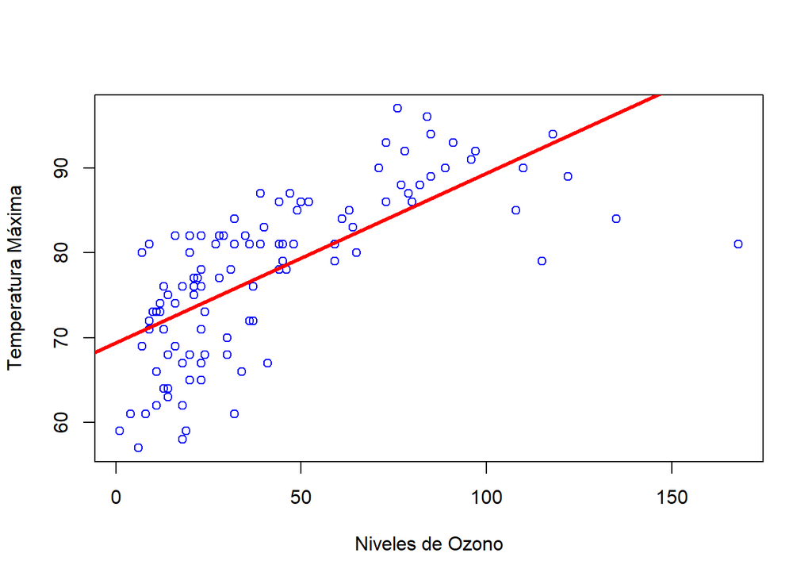

```r
plot(df$Ozone, df$Temp, col = "blue",
     xlab = "Niveles de Ozono", ylab = "Temperatura Máxima")
abline(model, col = "red", lwd = 3)
```

> Se representa gráficamente la relación entre ozono y temperatura, junto con la recta del modelo ajustado para observar visualmente la tendencia.

## Realizando predicciones

> Realizaremos una predicción usando el modelo antes creado, ubicando los valores en una matriz de 4 columnas donde: -fit: valor predicho -lwr: Límite inferior del intervalo -upr: Límite superior del intervalo

```r
#data frame que contiene valores a partir del valor máximo de Ozone hasta 200 con pasos entre ellos iguales a 2
data_model  <- data.frame(Ozone = seq(max(df$Ozone), 200, by = 2))
#calcula las predicciones para estos valores utilizando el modelo de regresión
predict_model <- predict(model, newdata = data_model, interval = "prediction")
#combina las columnas de data_model y predict_model
results_model <- cbind(data_model, predict_model)
results_model
```

```
##    Ozone      fit      lwr      upr
## 1    168 102.9801 88.48862 117.4716
## 2    170 103.3802 88.86225 117.8982
## 3    172 103.7803 89.23551 118.3251
## 4    174 104.1804 89.60841 118.7525
## 5    176 104.5806 89.98094 119.1802
## 6    178 104.9807 90.35311 119.6082
## 7    180 105.3808 90.72492 120.0366
## 8    182 105.7809 91.09637 120.4654
## 9    184 106.1810 91.46747 120.8946
## 10   186 106.5811 91.83821 121.3240
## 11   188 106.9812 92.20860 121.7539
## 12   190 107.3813 92.57864 122.1841
## 13   192 107.7815 92.94834 122.6146
## 14   194 108.1816 93.31769 123.0455
## 15   196 108.5817 93.68669 123.4767
## 16   198 108.9818 94.05536 123.9082
## 17   200 109.3819 94.42369 124.3401
```

> Con estos resultados se puede ver como a medida que aumenta el Ozono la temperatura crece hasta llegar a 109ºF, esto es mayor que la temperatura máxima registrada en Nueva York (106ºF en 1936). Por tanto continuemos analizando nuestro modelo para determinar su viabilidad utilizando el modelo de normalizacion Q-Q para ver si los residuos son normales.

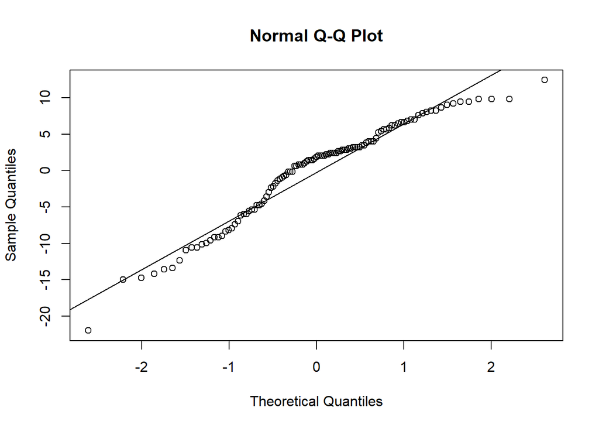

```r
residuos_model <- residuals(model)#contiene los residuos del modelo
#gráfica del modelo Q-Q con la linea de la norma
qqnorm(residuos_model)
qqline(residuos_model)
```

```r
#realizamos la prueba de Shapiro-Wilk para determinar el p-valor resultante
shapiro.test(residuos_model)
```

```
##
##  Shapiro-Wilk normality test
##
## data:  residuos_model
## W = 0.9506, p-value = 0.000432
```

# Conclusión

El trabajo demuestra cómo un AED bien estructurado puede ir más allá de lo descriptivo y convertirse en una herramienta para **generar hipótesis, motivar líneas de investigación y contextualizar fenómenos ambientales contemporáneos**. Además, destaca la importancia de la visualización, el uso de métricas robustas como el percentil 95 y la integración de distintas variables para identificar fenómenos multicausales.

Finalmente, este estudio reafirma el valor del análisis exploratorio como una etapa clave en cualquier investigación científica basada en datos. La habilidad de traducir datos en preguntas relevantes y patrones significativos es lo que define la calidad de un analista de datos, y este proyecto ha sido una muestra de ese enfoque crítico, riguroso y reflexivo.